# Exam_2

Jonathan De Los Santos

## Part A

*a) Create a histogram and q-q plot for daily return variable; dow$return and state what is the distribution of daily returns?*

The long tails make this difficult to read, but this distribution does appear to skew left. Given the dataset, it wouldn’t be surprising that recessions/depressions cause more outliers to the left than booms due to the right.

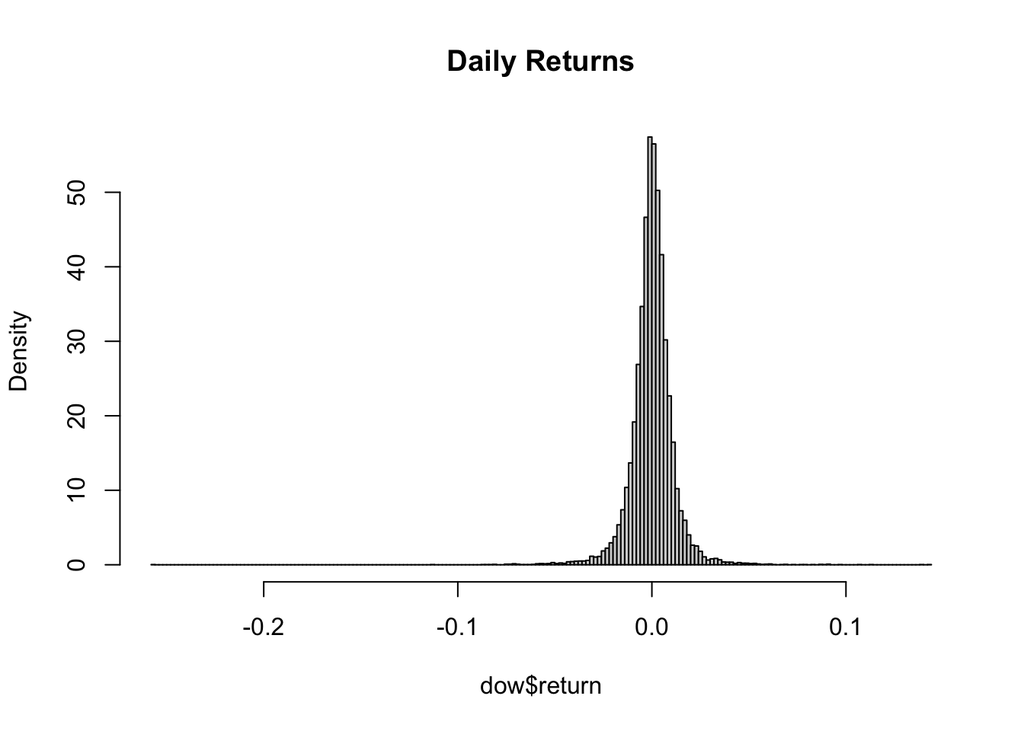

```r
dow = read.csv("http://tiny.cc/djia")

# Tried different break options for more visibility
hist(dow$return, breaks = 'scott', freq = FALSE, main = paste('Daily Returns'))
```

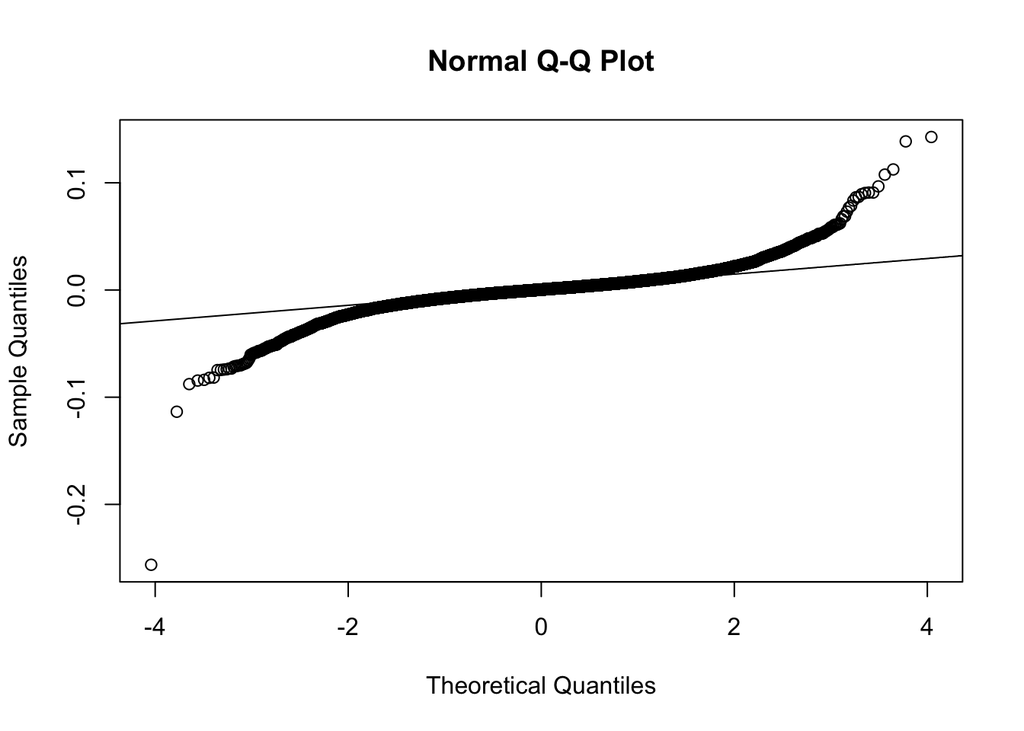

```r
qqnorm(dow$return)
qqline(dow$return)
```

## Part B

*b) Find a 95% confidence interval for the daily return. What does this show?*

If my calculations are correct, the 95% confidence interval is between 4.04 x $10^{-5}$ and 3.6 x $10^{-4}$ which indicates that with 95% confidence a random day’s return will average between .0000404 and .00036. This is an extremely narrow window likely due to the high sample size.

My result seems a little off because the histogram indicates values out to well past 0 and .01, but it could be that the density of values with that range is so high that it still applies.

```r
# Starting with t.test to compare manual results
# Also gives me df without doing a count
dow = read.csv("http://tiny.cc/djia")

# Having issues when I use "dow" so I will proceed calling the column from the data
t.test(dow$return, alternative = 'two.sided' ,conf.level = .95)
```

```
##
##  One Sample t-test
##
## data:  dow$return
## t = 2.4558, df = 18833, p-value = 0.01407
## alternative hypothesis: true mean is not equal to 0
## 95 percent confidence interval:
##  4.041003e-05 3.599686e-04
## sample estimates:
##    mean of x
## 0.0002001893
```

```r
n = length(dow$return)
# Manually calculate df to be sure
df = length(dow$return) - 1
alpha = .05
sd = sd(dow$return)
Xbar = mean(dow$return)

# Get upper and lower bounds with t-score and standard error
lb = Xbar - qt(alpha/2, df) * sd/sqrt(n)
ub = Xbar + qt(alpha/2, df) * sd/sqrt(n)
c(lb, ub)
```

```
## [1] 3.599686e-04 4.041003e-05
```

## Part C

*c) Perform a hypothesis test at alpha = 0.01 assuming that* *H0: Mean Daily Return >= 0* *Ha: Mean Daily return < 0*

The resulting T-stat is not less than the critical value, therefore we fail to reject the null hypothesis that mean daily return >= 0.

```r
# Null hypothesis
mu0 = 0

n = length(dow$return)

df = length(dow$return) - 1
alpha = .01
sd = sd(dow$return)
xbar = mean(dow$return)

# Null distribution parameters
muXbar = mu0
sigmaXbar = sd/sqrt(n)

# Find test statistic
Tstat = (xbar - mu0)/(sd/sqrt(n))
print(paste('Tstat: ', Tstat ))
```

```
## [1] "Tstat:  2.45581945104101"
```

```r
# Check significance
# Use < because of alt hypothesis, looking at left tail
print(paste('Critical value: ', qt(1-alpha, df) ))
```

```
## [1] "Critical value:  2.326545897615"
```

```r
print(paste('Is Tstat < critical value? ', Tstat < qt(1-alpha, df) ))
```

```
## [1] "Is Tstat < critical value?  FALSE"
```

```r
print(paste('Probability that T < Tstat: ',  pt(Tstat, df) ))
```

```
## [1] "Probability that T < Tstat:  0.992967329026086"
```